# Case Study Report: Bellabeat Wellness Insights

2025-09-22

Author: Aakif Altaf

# Introduction

This case study explores **smart device usage data** from Fitbit to uncover patterns in activity, sleep, and wellness behavior.  
Our goal is to generate actionable insights that Bellabeat, a wellness technology company, can use to improve its **marketing strategies and product offerings**.

The analysis follows a structured data analysis approach:  
- **Ask**: What patterns exist in activity, sleep, and calories burned?  
- **Prepare**: Clean and merge Fitbit datasets.  
- **Process**: Explore and visualize relationships between variables.  
- **Analyze**: Identify correlations and trends.  
- **Share**: Present findings with clear plots and narrative.  
- **Act**: Recommend strategies for Bellabeat’s products and campaigns.

# Libraries & Data Import

```
Imported and explored multiple CSV files using readr and dplyr

Cleaned and merged datasets using distinct(), drop_na(), and inner_join()

Verified data integrity and structure (wide vs. long format)

Assessed credibility using the ROCCC framework (Reliable, Original, Comprehensive, Current, Cited)
```

Data summary

| Name | daily_activity |
| --- | --- |
| Number of rows | 457 |
| Number of columns | 15 |
| _______________________ |  |
| Column type frequency: |  |
| Date | 1 |
| numeric | 14 |
| ________________________ |  |
| Group variables | None |

**Variable type: Date**

| skim_variable | n_missing | complete_rate | min | max | median | n_unique |
| --- | --- | --- | --- | --- | --- | --- |
| activity_date | 0 | 1 | 2016-03-12 | 2016-04-12 | 2016-04-05 | 32 |

**Variable type: numeric**

Data summary

| skim_variable | n_missing | complete_rate | mean | sd | p0 | p25 | p50 | p75 | p100 |
| --- | --- | --- | --- | --- | --- | --- | --- | --- | --- |
| id | 0 | 1 | 4.628595e+09 | 2.293781e+09 | 1503960366 | 2.347168e+09 | 4.057193e+09 | 6.391747e+09 | 8.877689e+09 |
| total_steps | 0 | 1 | 6.546560e+03 | 5.398490e+03 | 0 | 1.988000e+03 | 5.986000e+03 | 1.019800e+04 | 2.849700e+04 |
| total_distance | 0 | 1 | 4.660000e+00 | 4.080000e+00 | 0 | 1.410000e+00 | 4.090000e+00 | 7.160000e+00 | 2.753000e+01 |
| tracker_distance | 0 | 1 | 4.610000e+00 | 4.070000e+00 | 0 | 1.280000e+00 | 4.090000e+00 | 7.110000e+00 | 2.753000e+01 |
| logged_activities_distance | 0 | 1 | 1.800000e-01 | 8.500000e-01 | 0 | 0.000000e+00 | 0.000000e+00 | 0.000000e+00 | 6.730000e+00 |
| very_active_distance | 0 | 1 | 1.180000e+00 | 2.490000e+00 | 0 | 0.000000e+00 | 0.000000e+00 | 1.310000e+00 | 2.192000e+01 |
| moderately_active_distance | 0 | 1 | 4.800000e-01 | 8.300000e-01 | 0 | 0.000000e+00 | 2.000000e-02 | 6.700000e-01 | 6.400000e+00 |
| light_active_distance | 0 | 1 | 2.890000e+00 | 2.240000e+00 | 0 | 8.700000e-01 | 2.930000e+00 | 4.460000e+00 | 1.251000e+01 |
| sedentary_active_distance | 0 | 1 | 0.000000e+00 | 1.000000e-02 | 0 | 0.000000e+00 | 0.000000e+00 | 0.000000e+00 | 1.000000e-01 |
| very_active_minutes | 0 | 1 | 1.662000e+01 | 2.892000e+01 | 0 | 0.000000e+00 | 0.000000e+00 | 2.500000e+01 | 2.020000e+02 |
| fairly_active_minutes | 0 | 1 | 1.307000e+01 | 3.621000e+01 | 0 | 0.000000e+00 | 1.000000e+00 | 1.600000e+01 | 6.600000e+02 |
| lightly_active_minutes | 0 | 1 | 1.700700e+02 | 1.222100e+02 | 0 | 6.400000e+01 | 1.810000e+02 | 2.570000e+02 | 7.200000e+02 |
| sedentary_minutes | 0 | 1 | 9.952800e+02 | 3.370200e+02 | 32 | 7.280000e+02 | 1.057000e+03 | 1.285000e+03 | 1.440000e+03 |
| calories | 0 | 1 | 2.189450e+03 | 8.154800e+02 | 0 | 1.776000e+03 | 2.062000e+03 | 2.667000e+03 | 4.562000e+03 |

| Name | sleep_day |
| --- | --- |
| Number of rows | 410 |
| Number of columns | 5 |
| _______________________ |  |
| Column type frequency: |  |
| numeric | 4 |
| POSIXct | 1 |
| ________________________ |  |
| Group variables | None |

**Variable type: numeric**

| skim_variable | n_missing | complete_rate | mean | sd | p0 | p25 | p50 | p75 | p100 |
| --- | --- | --- | --- | --- | --- | --- | --- | --- | --- |
| id | 0 | 1 | 4.994963e+09 | 2.060863e+09 | 1503960366 | 3.977334e+09 | 4702921684.0 | 6962181067 | 8792009665 |
| total_sleep_records | 0 | 1 | 1.120000e+00 | 3.500000e-01 | 1 | 1.000000e+00 | 1.0 | 1 | 3 |
| total_minutes_asleep | 0 | 1 | 4.191700e+02 | 1.186400e+02 | 58 | 3.610000e+02 | 432.5 | 490 | 796 |
| total_time_in_bed | 0 | 1 | 4.584800e+02 | 1.274600e+02 | 61 | 4.037500e+02 | 463.0 | 526 | 961 |

**Variable type: POSIXct**

| skim_variable | n_missing | complete_rate | min | max | median | n_unique |
| --- | --- | --- | --- | --- | --- | --- |
| sleep_day | 0 | 1 | 2016-04-12 | 2016-05-12 | 2016-04-27 | 31 |

**I standardized and cleaned the datasets. For analysis, I focus mainly on daily activity and sleep records, merging them where possible.**

# Analysis & Insights

**Steps vs Calories**

**Question: Do more steps translate to more calories burned?**

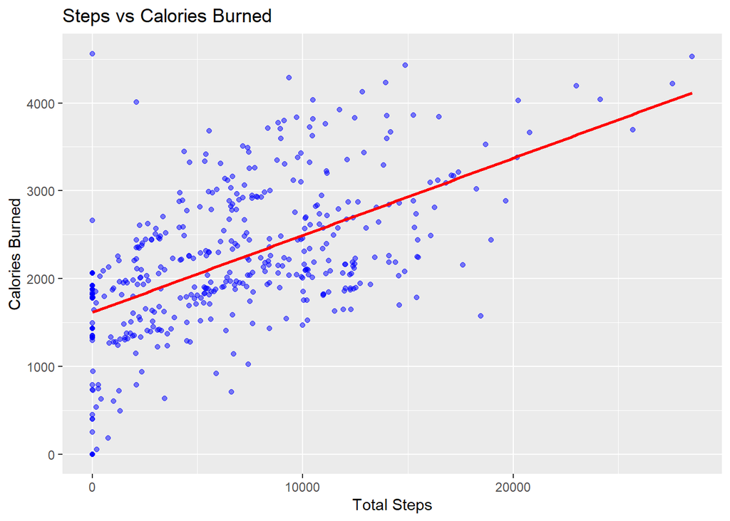

**Business Implication:**

Bellabeat can emphasize step challenges and activity goals in its marketing to highlight calorie-burning benefits.

# Sleep vs Activity

**Question: How does sleep duration affect activity levels?**

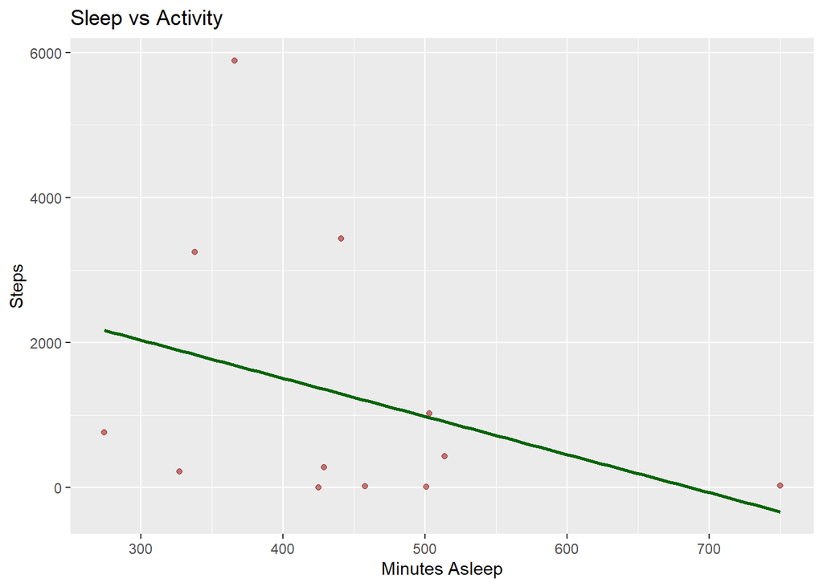

**Insight:**

**Business Implication:**

Bellabeat can encourage balanced routines—using notifications to promote consistent sleep while nudging users toward more daily movement.

# Weekly Activity Patterns

**Question: Are there patterns across weekdays?**

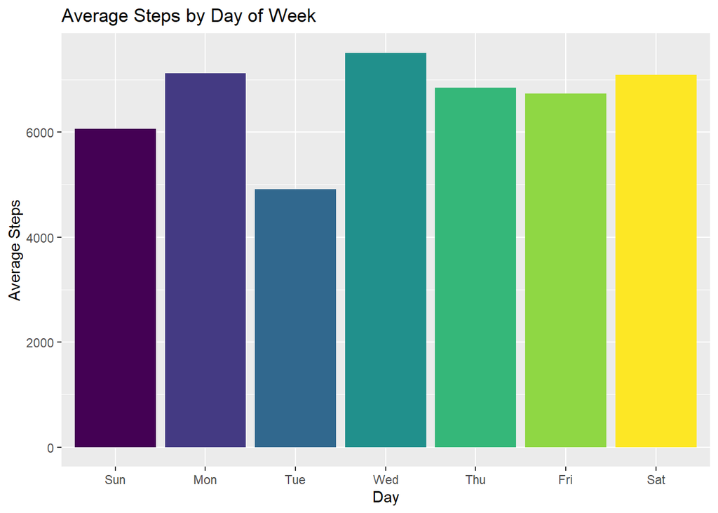

# Conclusions & Recommendations

**This analysis highlights opportunities for Bellabeat to improve user engagement and promote healthier lifestyles:**

**Use personalized notifications to promote sleep consistency and healthy routines.**

**Highlight calorie–step link in marketing to promote fitness through walking/activity tracking.**

**Promote balanced wellness by showing users how to manage both sleep and activity effectively.**

**By leveraging these data-driven insights, Bellabeat can enhance user wellness outcomes while strengthening its brand as a holistic smart health companion.**

# Thank You

Thank you for reviewing this case study. I appreciate your time and interest in my analysis. If you would like to discuss this project further or explore potential collaborations, feel free to connect with me on my Email: kmrtech99@gmail.com